# Specialty Coffee Analysis

Speciality Coffee Predictors Analysis

Eduardo Pacheco & Abert Figueras

23/02/2022

# 1 1. Overview

## 1.1 What is Specialty Coffee?

The term ‘Speciality coffee’ or ‘Specialty coffee’ is used to refer to coffee that is graded 80 points or above on a 100 point scale by a certified coffee taster from the *Specialty Coffee Association of Europe (SCAE)* or by a licensed Q Grader from the *Quality Coffee Institute (CQI)*.

Specialty coffees are coffees at their peak and are different to other coffee because specialty coffee has been grown at the perfect altitude, at the correct time of year, in the best soil, and then picked at just the right time. All this translates into some of the most exciting and tasty coffee in the world.

## 1.2 Specialty Coffee - Q Grade Score Sheet

| SCORE | GRADE | SPECIALITY YES/NO |
| --- | --- | --- |
| 90 - 100 | Outstanding | Specialty Coffee |
| 85 - 89.99 | Excellent | Specialty Coffee |
| 80 - 84.99 | Very Good | Specialty Coffee |
| Less than 80 | Below Specialty Coffee | Not Specialty Coffee |

## 1.3 Coffee Grading

Green coffee is graded via visual inspection and cupping. Visual inspection involves taking a 350g sample of green coffee beans and counting defective beans. Defects can be Primary (e.g. black beans, sour beans) or Secondary (e.g. broken beans). For a coffee to qualify as “specialty”, it must have zero Primary defects and less than five Secondary defects.

Cupping involves roasting the coffee and brewing simply with hot water, and relies on the skill of the taster to assign scores to each of the coffee’s attributes, such the acidity, body, flavor and aroma.

## 1.4 Growth of Specialty Coffee

In the USA, specialty coffee is spreading nationwide, daily consumption of specialty coffee in America has risen from 9% in 1999 to 34% in 2014.

Meanwhile, in the UK, a recent report by Allegra predicts that the specialty coffee market is set for a 13% year on year growth, higher than the 10% predicted for the coffee market as a whole. The result of speciality coffees increasing popularity is mirrored in high street chains, as Starbucks and Costa continue to introduce limited edition single origin coffees in stark contrast to their super-dark roasts or high robusta-content blends. Allegra’s report also predicted a doubling of the current 1,400 specialty coffee shops by 2020, and a year on year growth rate of 17% for the UK roasted specialty coffee market.

In this context, we have decided to analyse a sample of 1339 specialty coffees from all over the world, with the purpose of identify which are the main factor that influence the coffee grading total score.

# 2 2. Introduction

## 2.1 2.1. Where the data comes from

We have extracted the data from a coffee trader here in Switzerland, it is a small sample from their data bank of coffees. We had tried to randomly select a representative sample from the large coffee portfolio of this company.

## 2.2 2.2. What the aims of the analysis are

We have decided to take the role of a coffee broker. In other words, a coffee broker is a coffee specialist whose mission is to search and discover new farms and suppliers. To have some guidelines and criteria to select the best candidates and collect samples, we are approaching this analysis under the following research question:

> “Which coffee characteristics (predictor variables) have the most significant influence in the cupper score (response variable) for Specialty Coffees, in the function of the criteria established by the European Coffee Association.”

# 3 3. Reshaping and Cleaning the Data Set

## 3.1 3.1. Importing the data set and selecting the useful columns:

```r
library(tidyr)
library(magrittr)
library(dplyr)
library(ggplot2)
library(corrplot)
library(gridExtra)
library(GGally)
library(broom)
```

```r
# Importing the data set
coffee_raw <- read.csv("merged_coffee_data.csv")
str(coffee_raw)


# Selecting useful columns:
colnames(coffee_raw)
coffee.selected <- coffee_raw %>%
  select(X, Species, Variety, Country.of.Origin, Processing.Method, Moisture,
         Category.One.Defects, Category.Two.Defects, Quakers, Aroma,
         Flavor, Aftertaste, Acidity, Body, Balance, Uniformity, Clean.Cup,
         Sweetness, Cupper.Points, Total.Cup.Points, altitude_mean_meters,
         unit_of_measurement, Harvest.Year, Grading.Date)
head(coffee.selected)

## Renaming the titles:
coffee <- coffee.selected %>%
  rename(ID = X,
         Country = Country.of.Origin,
         Cupper.Score = Cupper.Points,
         Total.Cup.Score = Total.Cup.Points,
         Mean.Altitude = altitude_mean_meters,
         Unit.of.Measurement = unit_of_measurement
         )
colnames(coffee)

## Creation of an ID for each coffee entry:
coffee$ID <- paste("C", c(1:length(coffee$Species)), sep ="-")
head(coffee$ID, n = 10)
```

## 3.2 3.2. Dealing with missing values

```r
# Wrangling Missing Values:
anyNA.data.frame(coffee)
colnames(coffee)

# Filling blank spaces in the column Variety
anyNA((coffee$Variety))
coffee$Variety[coffee$Variety ==""] <- "Other"
head(coffee$Variety,n = 20)

# Filling blank spaces in the column Country
anyNA((coffee$Country))
coffee$Country[coffee$Country == ""] <- "Unknown"
head(coffee$Country)

# Fixing fields with errors in column "Country":
coffee$Country[coffee$Country == "Cote d?Ivoire"] <- "Ivory Coast"
coffee$Country[coffee$Country == "United States (Hawaii)"] <- "United States"
coffee$Country[coffee$Country == "United States (Puerto Rico)"] <- "United States"
head(coffee$Country)

# Filling missing values with "Other" in the column "Processing.Method":
anyNA((coffee$Processing.Method))
coffee$Processing.Method[coffee$Processing.Method == ""] <- "Other"
head(coffee$Processing.Method)

# Checking for missing values:
colnames(coffee)

anyNA(coffee$Aroma)
anyNA(coffee$Flavor)
anyNA(coffee$Aftertaste)
anyNA(coffee$Acidity)
anyNA(coffee$Body)
anyNA(coffee$Balance)
anyNA(coffee$Uniformity)
anyNA(coffee$Clean.Cup)
anyNA(coffee$Sweetness)
anyNA(coffee$Balance)
anyNA(coffee$Cupper.Score)
anyNA(coffee$Total.Cup.Score)

## Converting "Mean.Altitude" from feet to meters:
anyNA(coffee$Mean.Altitude)
sum(is.na(coffee$Mean.Altitude))

anyNA(coffee$Unit.of.Measurement)
sum(coffee$Unit.of.Measurement == "ft")

counter.unit.feet <- coffee$Unit.of.Measurement == "ft"
coffee$Mean.Altitude[counter.unit.feet] <- coffee$Mean.Altitude[counter.unit.feet] * 0.3048
coffee$Mean.Altitude <- round(coffee$Mean.Altitude,1)
coffee$Unit.of.Measurement[counter.unit.feet] <- "m"
head(coffee$Mean.Altitude, n = 20)

#Removing the nonexistent altitude:
summary(coffee$Mean.Altitude)
coffee$Mean.Altitude[coffee$Mean.Altitude > 8848] <- "" #8848m World highest alt.
str(coffee$Mean.Altitude) #[1] chr [1:1339] "2075" "2075" "1700"...
coffee$Mean.Altitude <- as.numeric(coffee$Mean.Altitude)
str(coffee$Mean.Altitude) #[1] num [1:1339] 2075 2075 1700 ...
head(coffee$Mean.Altitude)

# Checking for more missing values:
colnames(coffee)

anyNA(coffee$Grading.Date)
anyNA(coffee$Moisture)
anyNA(coffee$Grading.Date)

View(coffee)
```

# 4 4. Visualizing the Data

## 4.1 4.1. Relevant Bean and Farm Metadata

Summary of Species, Processing.Method, Moisture and Mean.Altitude

|  | Species | Processing.Method | Moisture | Mean.Altitude |
| --- | --- | --- | --- | --- |
|  | Length:1338 | Length:1338 | Min. :0.00000 | Min. : 1 |
|  | Class :character | Class :character | 1st Qu.:0.09000 | 1st Qu.: 950 |
|  | Mode :character | Mode :character | Median :0.11000 | Median :1300 |
|  |  |  | Mean :0.08836 | Mean :1238 |
|  |  |  | 3rd Qu.:0.12000 | 3rd Qu.:1600 |
|  |  |  | Max. :0.28000 | Max. :4287 |
|  |  |  |  | NA’s :234 |

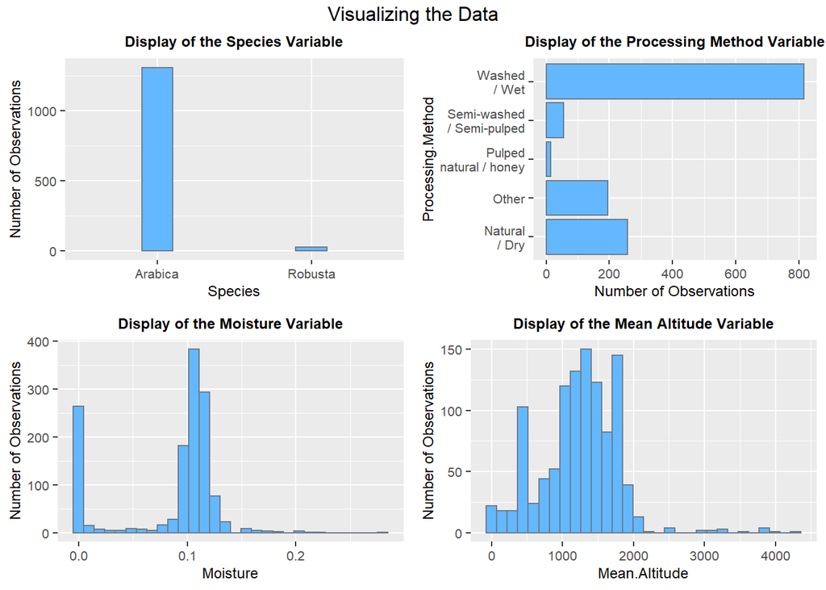

## 4.2 4.2. Visualizing Country and Variety

Summary of Country and Variety

|  | Variety | Country |
| --- | --- | --- |
|  | Length:1338 | Length:1338 |
|  | Class :character | Class :character |
|  | Mode :character | Mode :character |

It is interesting to see which are the biggest producers in the world. We observe in the top 5, four well known Latin-American coffee countries and surprisingly the United States.

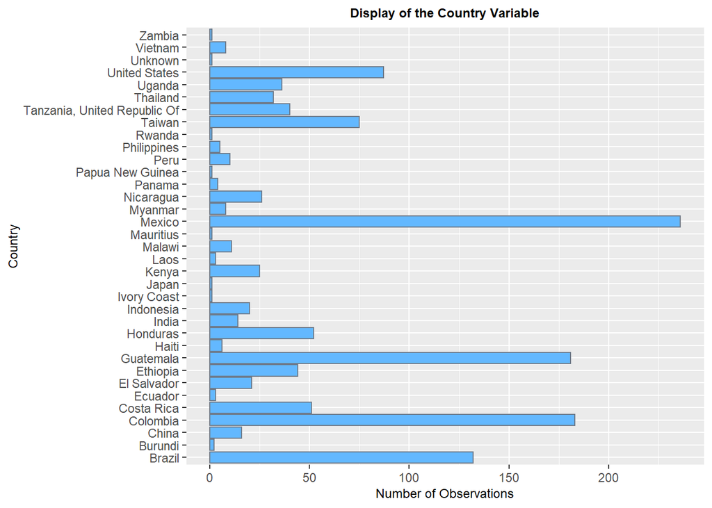

As it would be expected for coffee experts. In the top 3, the most common varieties of arabica coffee beans, Caturra, Bourbon and Typica. It is quite unfortunate to have such a large proportion of unknown varieties in our sample. Nevertheless, the sample reflects what we can see in the trading market

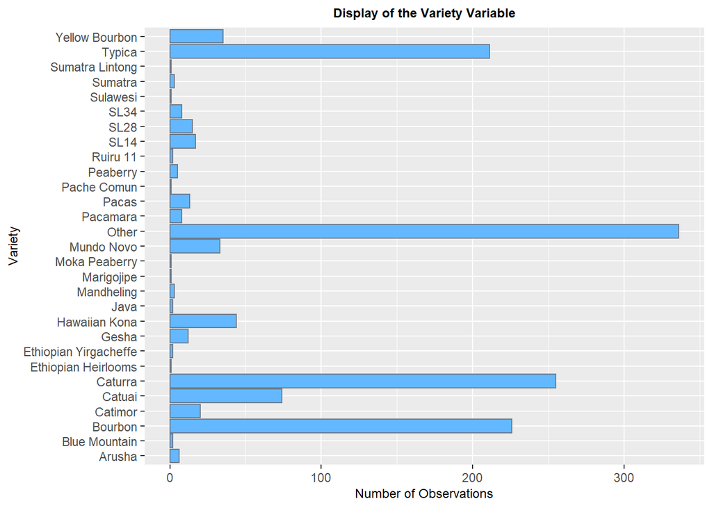

## 4.3 4.3. Visualizing Coffee Characteristics

The variable “Total.Cup.Points” was not considered since it is the result of adding all measured values. The idea here is to identify the correlation among coffee characteristics and Cupper.Score. Moisture and Defects are not considered in the following correlation matrix.

Coffee Characteristics:

```
- Aroma
- Flavor
- Aftertaste
- Acidity
- Body
- Balance
- Uniformity
- Cup Cleanliness
- Sweetness
- Moisture
- Defects
```

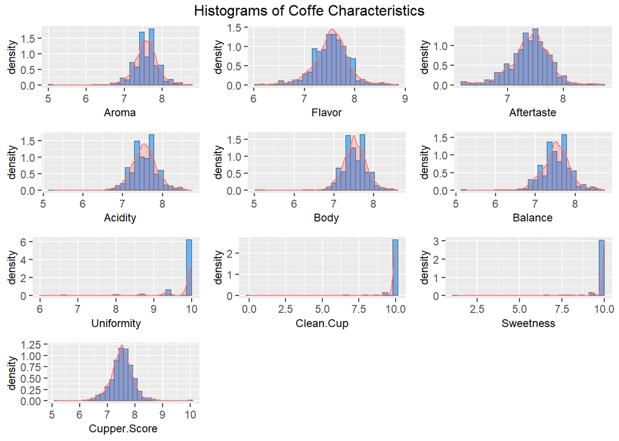

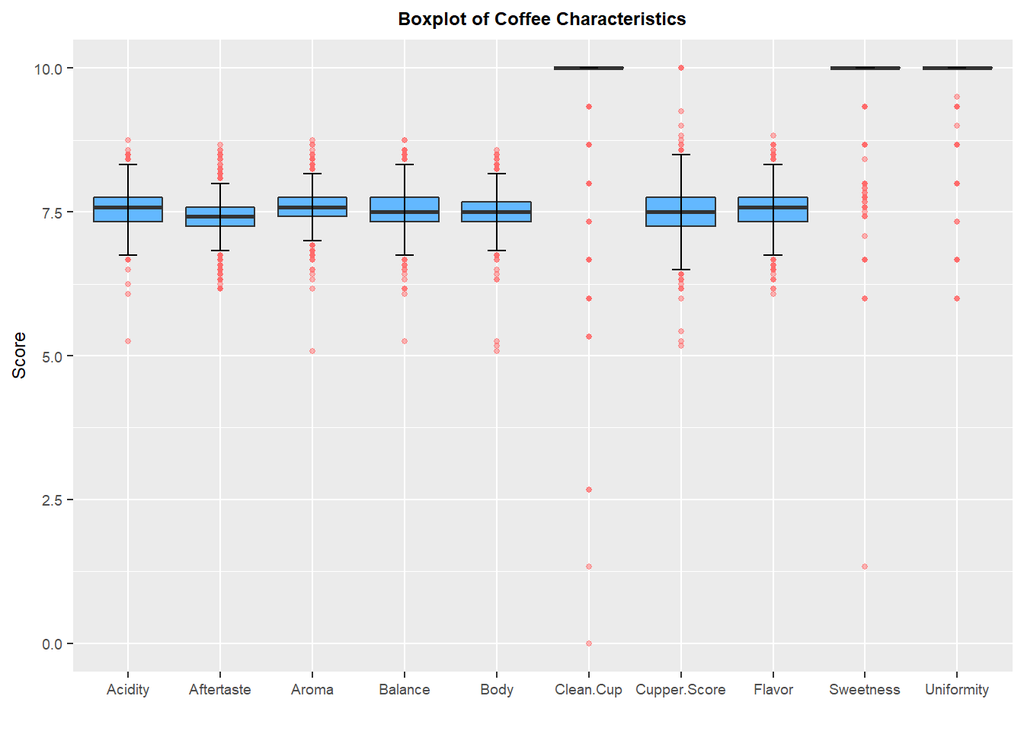

We are printing out a table with the correlation values with the function cor(), as it is visually not possible to quantify the correlation.

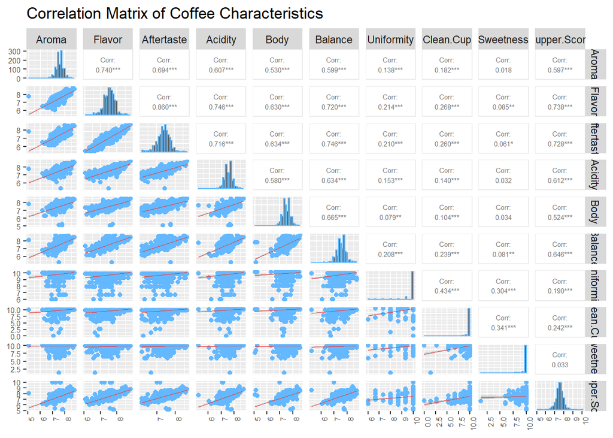

```r
lowerFn <- function(data, mapping, method = "lm", ...) {
  p <- ggplot(data = data, mapping = mapping) +
    geom_point(colour = "steelblue1") +
    geom_smooth(method = method, color = "firebrick1", ...)
  p
}

pairs.correlation <- ggpairs(
  coffee[, 10:19], lower = list(continuous = wrap(lowerFn, method = "lm", size = 0.3)),
  diag = list(continuous = wrap("barDiag", colour = "steelblue1")),
  upper = list(continuous = wrap("cor", size = 2)),
  title = "Correlation Matrix of Coffee Characteristics") +
  theme(axis.text.x = element_text(angle = 90, hjust = 1, size=6),
        axis.text.y = element_text(size = 6))

pairs.correlation
```

It would be other ways to visualize the interaction between each variable than simply observing at the table produced by the cor() function. For this reason we have chosen as **Chapter of choice”** the package “corrplot”, which allows us to visualize in a suitable way the correlation values from the pairs() function.

```r
# Correlations Values
correlation <- round(cor(coffee[,10:19]),2)
kable(correlation, align = c("c"), caption = "Coffee characteristics correlations")
```

Coffee characteristics correlations

|  | Aroma | Flavor | Aftertaste | Acidity | Body | Balance | Uniformity | Clean.Cup | Sweetness | Cupper.Score |
| --- | --- | --- | --- | --- | --- | --- | --- | --- | --- | --- |
| Aroma | 1.00 | 0.74 | 0.69 | 0.61 | 0.53 | 0.60 | 0.14 | 0.18 | 0.02 | 0.60 |
| Flavor | 0.74 | 1.00 | 0.86 | 0.75 | 0.63 | 0.72 | 0.21 | 0.27 | 0.08 | 0.74 |
| Aftertaste | 0.69 | 0.86 | 1.00 | 0.72 | 0.63 | 0.75 | 0.21 | 0.26 | 0.06 | 0.73 |
| Acidity | 0.61 | 0.75 | 0.72 | 1.00 | 0.58 | 0.63 | 0.15 | 0.14 | 0.03 | 0.61 |
| Body | 0.53 | 0.63 | 0.63 | 0.58 | 1.00 | 0.67 | 0.08 | 0.10 | 0.03 | 0.52 |
| Balance | 0.60 | 0.72 | 0.75 | 0.63 | 0.67 | 1.00 | 0.21 | 0.24 | 0.08 | 0.65 |
| Uniformity | 0.14 | 0.21 | 0.21 | 0.15 | 0.08 | 0.21 | 1.00 | 0.43 | 0.30 | 0.19 |
| Clean.Cup | 0.18 | 0.27 | 0.26 | 0.14 | 0.10 | 0.24 | 0.43 | 1.00 | 0.34 | 0.24 |
| Sweetness | 0.02 | 0.08 | 0.06 | 0.03 | 0.03 | 0.08 | 0.30 | 0.34 | 1.00 | 0.03 |
| Cupper.Score | 0.60 | 0.74 | 0.73 | 0.61 | 0.52 | 0.65 | 0.19 | 0.24 | 0.03 | 1.00 |

# 5 5. Chapter of Choice

R package corrplot provides a visual exploratory tool on correlation matrix that supports automatic variable reordering to help detect hidden patterns among variables.

Corrplot is very easy to use and provides a rich array of plotting options in visualization method, graphic layout, color, legend, text labels, etc. It also provides p-values and confidence intervals to help users determine the statistical significance of the correlations.

corrplot() has about 50 parameters, however the mostly common ones are only a few. We can get a correlation matrix plot with only one line of code in most scenes. The mostly using parameters include method, type, order, diag, and etc.

There are seven visualization methods (parameter method) in corrplot package, named ‘circle’, ‘square’, ‘ellipse’, ‘number’, ‘shade’, ‘color’, ‘pie’. Color intensity of the glyph is proportional to the correlation coefficients by default color setting.

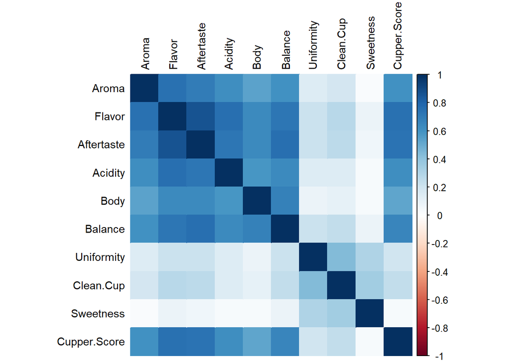

```r
library(corrplot)
corrplot(correlation, method="color", tl.cex = 0.9, tl.col = "black")
```

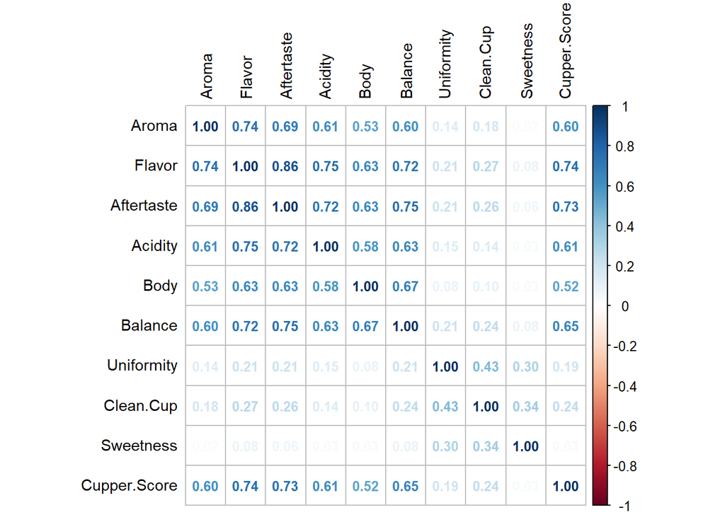

```r
library(corrplot)
corrplot(correlation, method="number", number.cex = 0.8, tl.cex = 0.9, tl.col = "black")
```

A nice combination of two different methods:

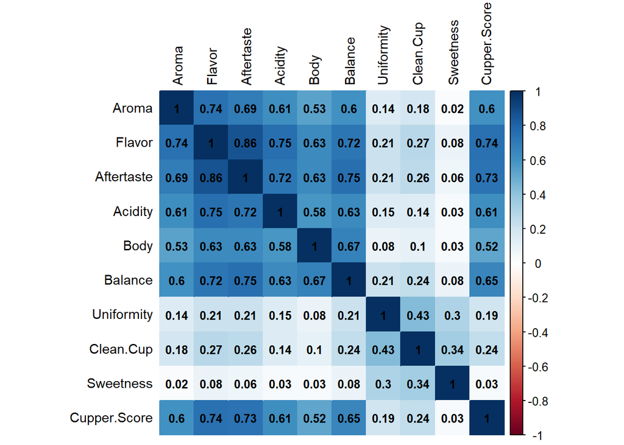

```r
corrplot(correlation, method = 'color', order = 'original', addCoef.col = 'black',
         number.cex = 0.8, tl.cex = 0.9, tl.col = "black")
```

# 6 6. Fitting Statistical Models

## 6.1 6.1. Categorical Variables

Categorical variables cannot be analysed the same way as continuous variables. For this reason, we will not try to fit linear models to find insights, except for Species. Instead we will be doing Box plots.

**6.1.1. Total cup score by Specie:**

Formulate null hypothesis and alternative hypothesis

> Null hypothesis: Arabica and Robusta have the same mean.  
> $Ho : \mu Ar = \mu Ro$

> Alternative Hypothesis: Arabica and Robusta means are NOT equal.  
> $Ha : \mu Ar \ne \mu B$

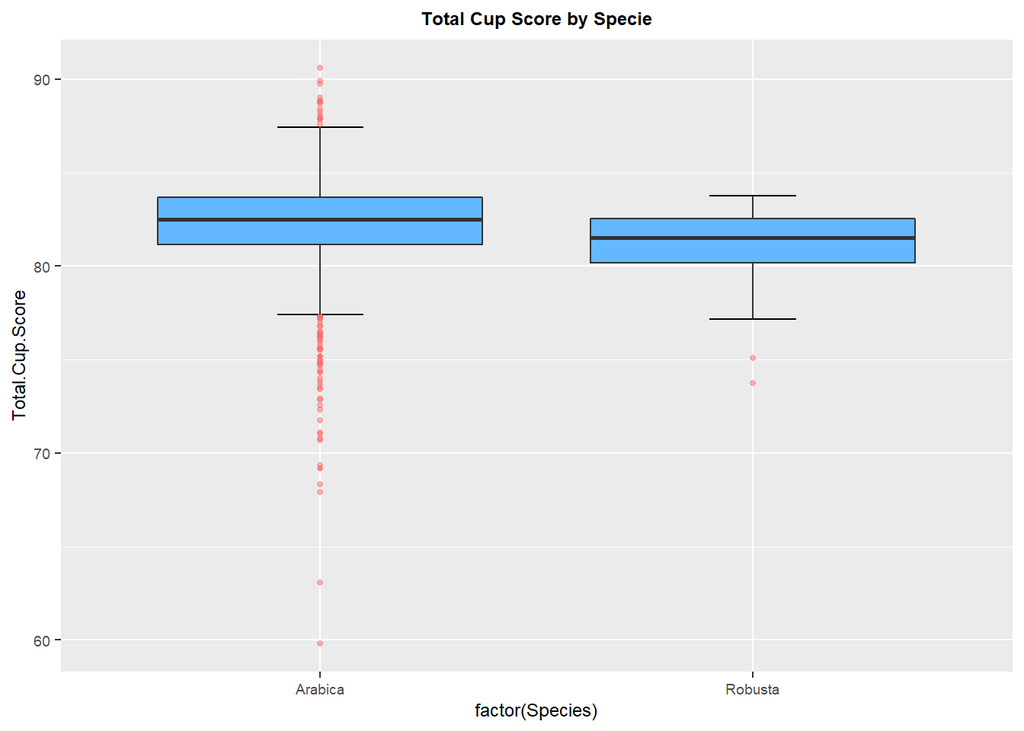

```
##
##  Welch Two Sample t-test
##
## data:  Total.Cup.Score by Species
## t = 2.8028, df = 28.415, p-value = 0.009028
## alternative hypothesis: true difference in means between group Arabica and group Robusta is not equal to 0
## 95 percent confidence interval:
##  0.353131 2.266233
## sample estimates:
## mean in group Arabica mean in group Robusta
##              82.17861              80.86893
```

```r
t.test(Total.Cup.Score ~ Species, data = coffee, altervative = "two.sided", )

ggplot(data = coffee,
       mapping = aes(y = Total.Cup.Score,
                     x = factor(Species))) +
  ggtitle("Total Cup Score by Specie") +
  theme(plot.title = element_text(hjust = 0.5,
                                  size = 9,
                                  face = "bold"),
        axis.text = element_text(size = 7),
        axis.title = element_text(size = 9)) +
  stat_boxplot(geom = "errorbar", width = 0.2) +
  geom_boxplot(fill = "steelblue1",
               outlier.colour = "indianred1",
               outlier.alpha = 0.5,
               outlier.size = 1)
```

*The p-value = 0.009028 makes us reject the Null Hypothesis.*

*We can obtain several insights, just to mention some:*

> *Both species, Arabica and Robusta, have similar smallest “normal observation. Both interquartile ranges have approximately the same size, but Arabicas start one point higher.*

> There is none robiusta coffee to be found over 84 points. On the other hand,  
> about 25% of arabica coffees score 84 points of higher

**6.1.2. Total cup score by Variety:**

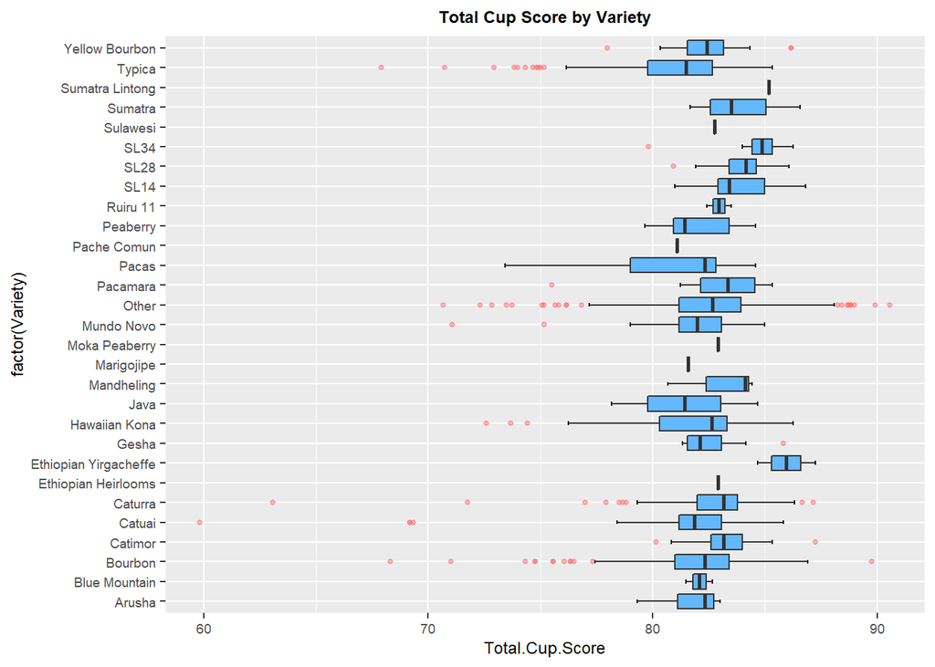

```r
ggplot(data = coffee,
       mapping = aes(x = Total.Cup.Score,
                     y = factor(Variety))) +
  ggtitle("Total Cup Score by Variety") +
  theme(plot.title = element_text(hjust = 0.5,
                                  size = 9,
                                  face = "bold"),
        axis.text = element_text(size = 7),
        axis.title = element_text(size = 9)) +
  stat_boxplot(geom = "errorbar", width = 0.2) +
  geom_boxplot(fill = "steelblue1",
               outlier.colour = "indianred1",
               outlier.alpha = 0.5,
               outlier.size = 1)
```

*We can obtain several insights, just to mention some:*

> *Most varieties have the lower quartile over the 80 points border to qualify as of specialty coffee, excepting Typica, Pacas and Java.*

**6.1.3. Total cup score by Country:**

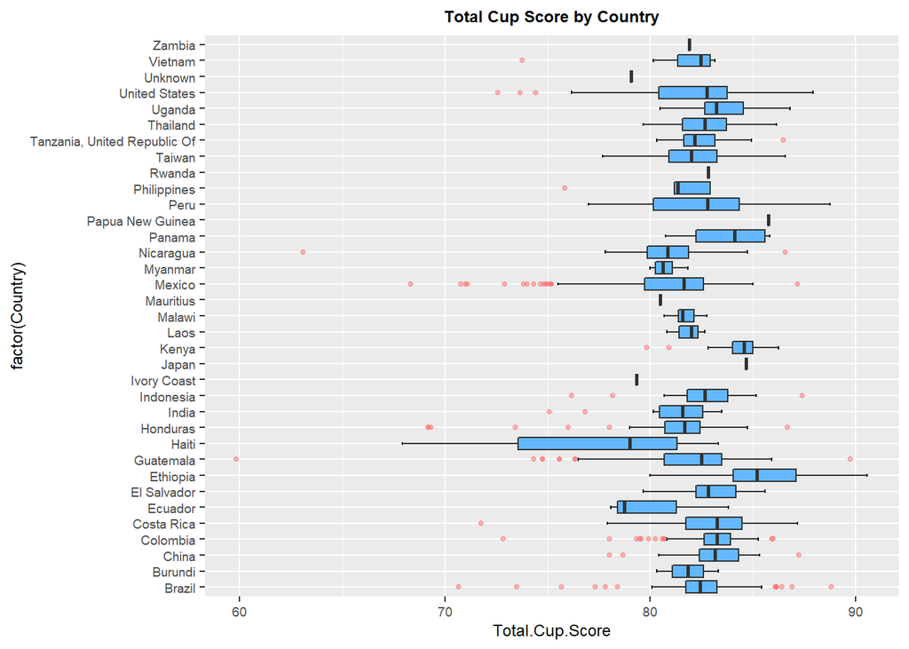

```r
ggplot(data = coffee,
       mapping = aes(x = Total.Cup.Score,
                     y = factor(Country))) +
  ggtitle("Total Cup Score by Country") +
  theme(plot.title = element_text(hjust = 0.5,
                                  size = 9,
                                  face = "bold"),
        axis.text = element_text(size = 7),
        axis.title = element_text(size = 9)) +
  stat_boxplot(geom = "errorbar", width = 0.2) +
  geom_boxplot(fill = "steelblue1",
               outlier.colour = "indianred1",
               outlier.alpha = 0.5,
               outlier.size = 1)
```

*We can obtain several insights, just to mention some:*

> *Countries like Kenya and Ethiopia have the highest media value in the sample, Kenya has 99% of its coffee samples between 83 to 86 points, and 50% between 84 to 85. Which tells well about the consistence in its coffee quality.*

> *On the other hand, Ethiopia has coffees with higher scores, but scores more spread out between 80 to 91 points. Nevertheless, Ethiopia has the largest proportion of very high quality coffees from the whole sample.*

**6.1.4. Total cup score by Processing Method:**

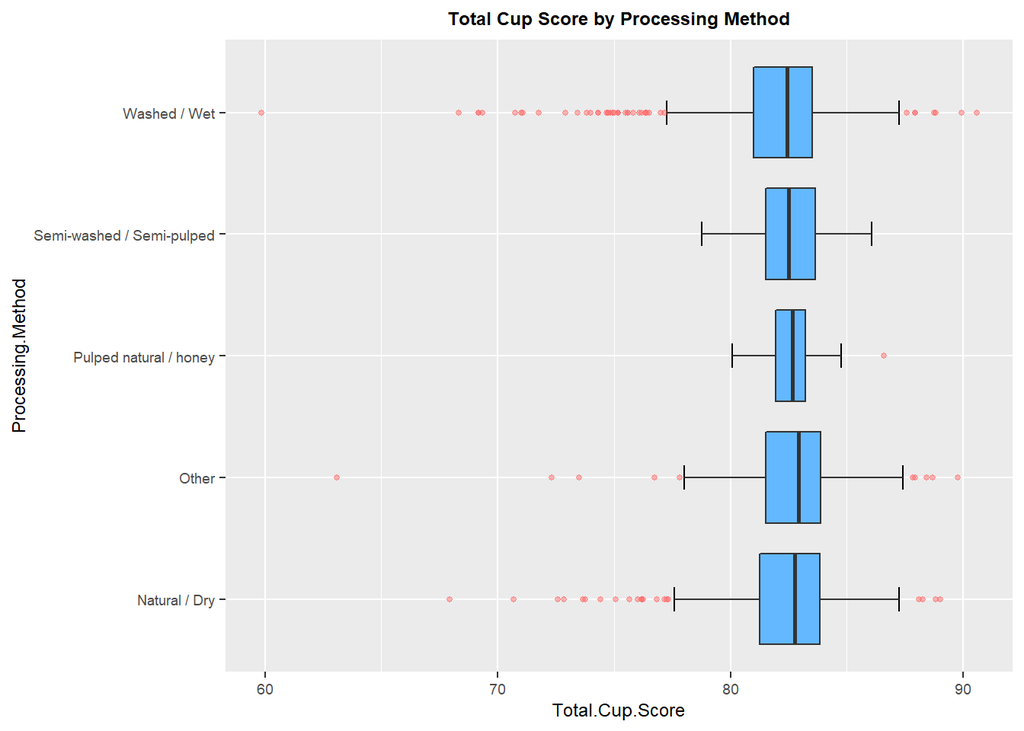

```r
ggplot(data = coffee,
       mapping = aes(x = Total.Cup.Score,
                     y = Processing.Method)) +
  ggtitle("Total Cup Score by Processing Method") +
  theme(plot.title = element_text(hjust = 0.5,
                                  size = 9,
                                  face = "bold"),
        axis.text = element_text(size = 7),
        axis.title = element_text(size = 9)) +
  stat_boxplot(geom = "errorbar", width = 0.2) +
  geom_boxplot(fill = "steelblue1",
               outlier.colour = "indianred1",
               outlier.alpha = 0.5,
               outlier.size = 1)
```

*We can obtain several insight, just to mention some:*

> *All the coffees have approximately the same median and interquartile range over 81 points, from the processing method perspective.*

> *The processing methods Washed/Wet and Natural/Dry have the largest spread, and Pulped natural/honey the smallest, also proving to be the only group to have 100% of its coffees classified as specialty coffees.

## 6.2 6.2. Fitting Models in Continuous Variables

Here again, we will not be using the variable “Total.Cup.Points” as the response variable since it is the result of adding all measured values. Instead, we will use “Cupper.Score” to run linear models in function of the coffee characteristics.

**6.2.1. Cupper Score in function of the Moisture**

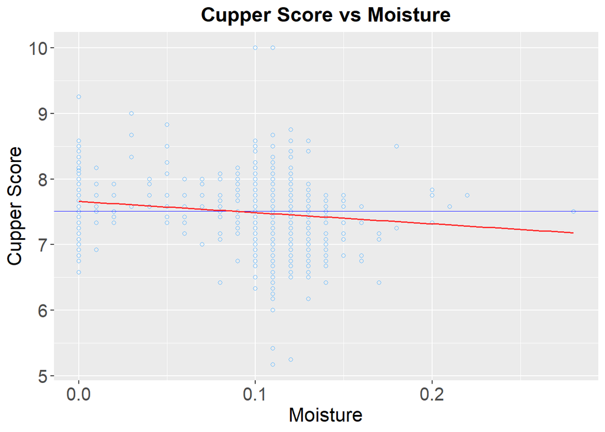

```
##
## Call:
## lm(formula = Cupper.Score ~ Moisture, data = coffee)
##
## Residuals:
##      Min       1Q   Median       3Q      Max
## -2.30198 -0.22198  0.01092  0.21511  2.52802
##
## Coefficients:
##             Estimate Std. Error t value Pr(>|t|)
## (Intercept)  7.66002    0.02389 320.703  < 2e-16 ***
## Moisture    -1.70946    0.23722  -7.206 9.59e-13 ***
## ---
## Signif. codes:  0 '***' 0.001 '**' 0.01 '*' 0.05 '.' 0.1 ' ' 1
##
## Residual standard error: 0.4189 on 1336 degrees of freedom
## Multiple R-squared:  0.03741,    Adjusted R-squared:  0.03669
## F-statistic: 51.93 on 1 and 1336 DF,  p-value: 9.595e-13
```

```r
fit.cupperscore.moisture <- lm(Cupper.Score  ~ Moisture, data = coffee)
summary(fit.cupperscore.moisture)

ggplot(data = coffee,
       mapping = aes(y = Cupper.Score,
                     x = Moisture)) +
  ggtitle("Cupper Score vs Moisture") +
  theme(plot.title = element_text(hjust = 0.5,
                                  size = 17,
                                  face = "bold"),
        axis.text = element_text(size = 15),
        axis.title = element_text(size = 16)) +
  xlab("Moisture") +
  ylab("Cupper Score") +
  geom_point(col="steelblue1", cex = 1.5, pch = 1) +
  geom_hline(yintercept = mean(coffee$Cupper.Score), colour = "blue", size = 0.3) +
  geom_smooth(method='lm', col="firebrick1", se=FALSE, size = 0.6)
```

We can describe our linear regression model with the following equation:
$$f(Cupper.Score) = {7.66} - {1.71}
Moisture$$

We obtain the following conclusions:

> *The p-values = 9.595e-13 confirms the high signicancy in therelation between the moisture and the cupper score.*

> *The aglomeration of dots in the plot between 0.9 and 0.14, confirms what the International Coffee Organization (ICO) states, that the ideal moisture content of green beans ready for roasting should be between 8% and 12.5%. This range is generally considered the optimum for factors such as cup quality.*

**6.2.2. Cupper Score in function of the One-defect Category**

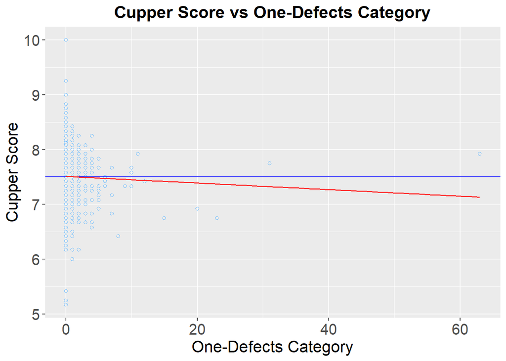

| term | estimate | std.error | statistic | p.value |
| --- | --- | --- | --- | --- |
| (Intercept) | 7.511861362 | 0.011870824 | 632.800347 | 0.0000000 |
| Category.One.Defects | -0.005997668 | 0.004575546 | -1.310809 | 0.1901475 |

```r
fit.cupperscore.onedefect <- lm(Cupper.Score  ~ Category.One.Defects, data = coffee)
tidy(fit.cupperscore.onedefect)

ggplot(data = coffee,
       mapping = aes(y = Cupper.Score,
                     x = Category.One.Defects)) +
  ggtitle("Cupper Score vs One-Defects Category") +
  theme(plot.title = element_text(hjust = 0.5,
                                  size = 17,
                                  face = "bold"),
        axis.text = element_text(size = 15),
        axis.title = element_text(size = 16)) +
  xlab("One-Defects Category") +
  ylab("Cupper Score") +
  geom_point(col="steelblue1", cex = 1.5, pch = 1) +
  geom_hline(yintercept = mean(coffee$Cupper.Score), colour = "blue", size = 0.3) +
  geom_smooth(method='lm', col="firebrick1", se=FALSE, size = 0.6)
```

We can describe our linear regression model with the following equation:
$$f(Cupper.Score) = {7.51} -
{0.006} Category.One.Defects$$

We obtain the following conclusions:

> *For one extra value in one-defect category, the cupper score decreases by 0.006. Which denotes a negative relation, the more defects, the lower the score.*

> *The p-values = 0.19 shows low signicancy in the relation between the cupper score and the one-defect category.*

**Note:** For all the graphs below, we will not show the code as it is a repetition of the latter. We have only adapted it to each study variable. Highlight that instead of the summary() function, we will continue to use the tidy() one.

**6.2.3. Cupper Score in function of the Two-defect category**

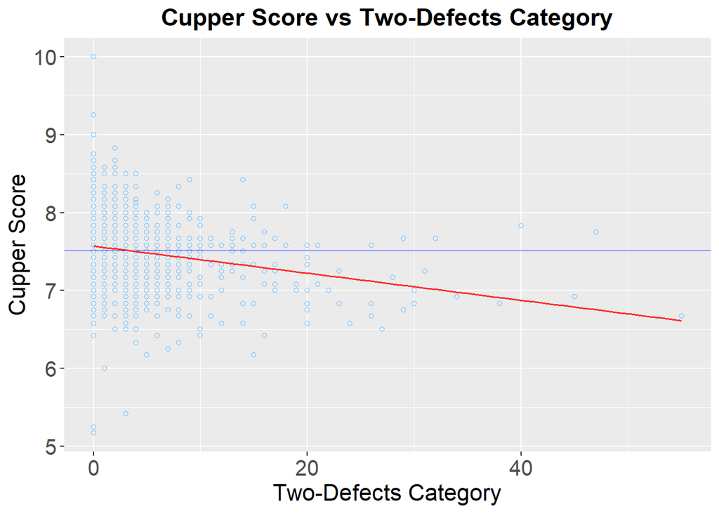

| term | estimate | std.error | statistic | p.value |
| --- | --- | --- | --- | --- |
| (Intercept) | 7.57088175 | 0.013715738 | 551.985007 | 0.000000e+00 |
| Category.Two.Defects | -0.01739911 | 0.002145247 | -8.110539 | 1.130522e-15 |

We obtain the following conclusions:

> *For one extra value in two-defect category, the cupper score decreases by 0.017. Which denotes a negative relation, the more defects, the lower the score.*

> *The p-values = 1.131e-15 shows high signicancy in the relation between the cupper score and the two-defect category.*

**6.2.4. Cupper Score in function of the Mean Altitude**

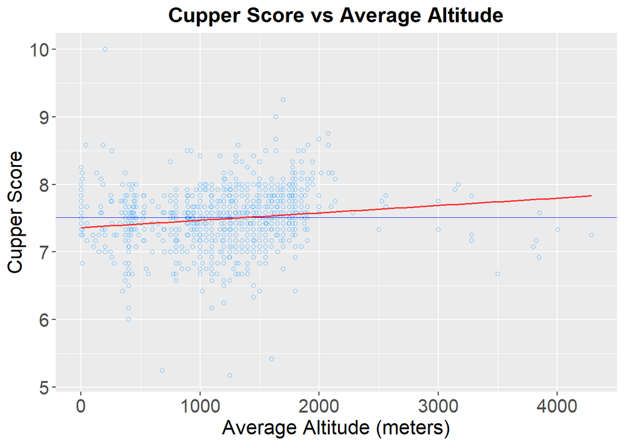

| term | estimate | std.error | statistic | p.value |
| --- | --- | --- | --- | --- |
| (Intercept) | 7.3609370925 | 3.006095e-02 | 244.867098 | 0.000000e+00 |
| Mean.Altitude | 0.0001092032 | 2.215188e-05 | 4.929749 | 9.497205e-07 |

We obtain the following conclusions:

> *For one extra value in mean altitude, the cupper score increase by 0.000109. Which denotes a positive relation, the more altitude, the higher the score.*

> *The p-values = 0.000000950 shows high signicancy in the relation between the cupper score and the mean altitude.*

## 6.3 6.3. Fitting Models in Coffee Characteristics

**6.3.1. Cupper Score in function of the Aroma**

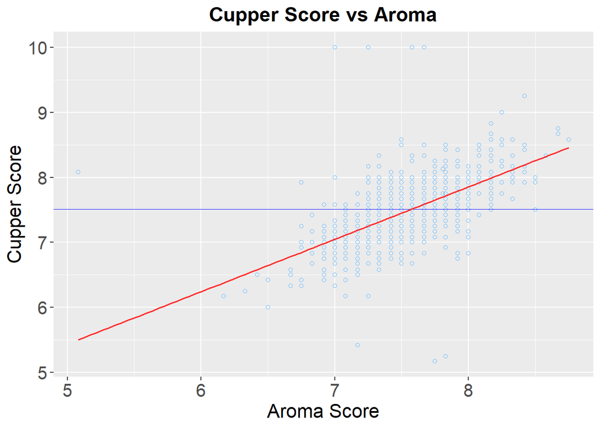

| term | estimate | std.error | statistic | p.value |
| --- | --- | --- | --- | --- |
| (Intercept) | 1.4045599 | 0.22482799 | 6.247264 | 5.603791e-10 |
| Aroma | 0.8061453 | 0.02966482 | 27.175130 | 8.033605e-130 |

We can describe our linear regression model with the following equation:
$$f(Cupper.Score) = {1.40} +
{0.806} Aroma$$

We obtain the following conclusions:

> *For one extra value in aroma, the cupper score increase by 0.806. Which denotes a positive relation, the more aroma, the higher the score.*

> *The p-values = 8.03e-130 shows high signicancy in the relation between the cupper score and the aroma.*

**6.3.2. Cupper Score in function of the Flavor**

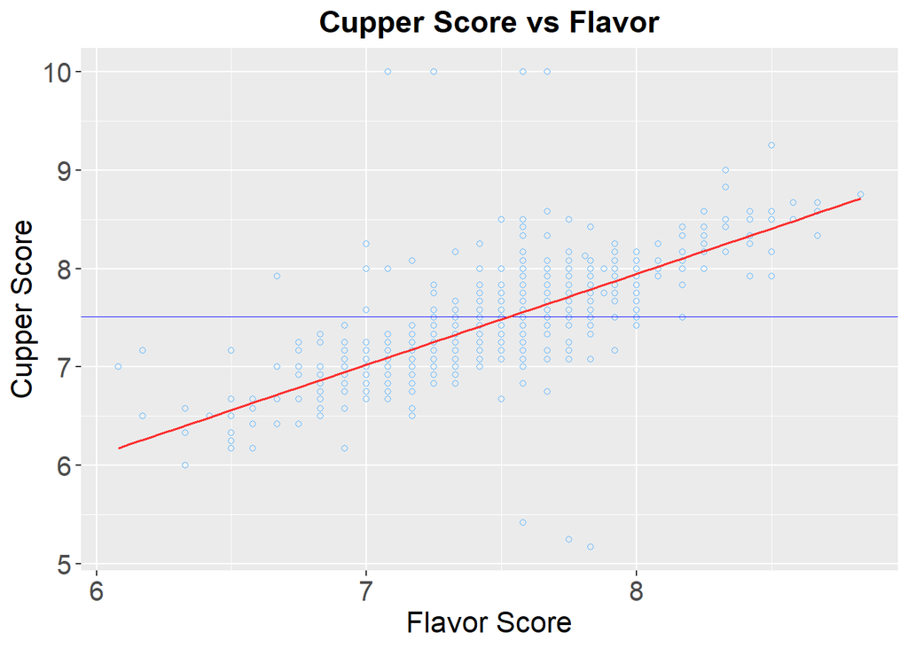

| term | estimate | std.error | statistic | p.value |
| --- | --- | --- | --- | --- |
| (Intercept) | 0.5661999 | 0.17396088 | 3.254754 | 1.163328e-03 |
| Flavor | 0.9225008 | 0.02309079 | 39.951035 | 2.725815e-230 |

We can describe our linear regression model with the following equation:
$$f(Cupper.Score) = {0.57} +
{0.923} Flavor$$

We obtain the following conclusions:

> *For one extra value in flavor, the cupper score increase by 0.923. Which denotes a positive relation, the more flavor, the higher the score.*

> *The p-values = 2.73e-230 shows high signicancy in the relation between the cupper score and the flavor.*

**6.3.3. Cupper Score in function of the Aftertaste**

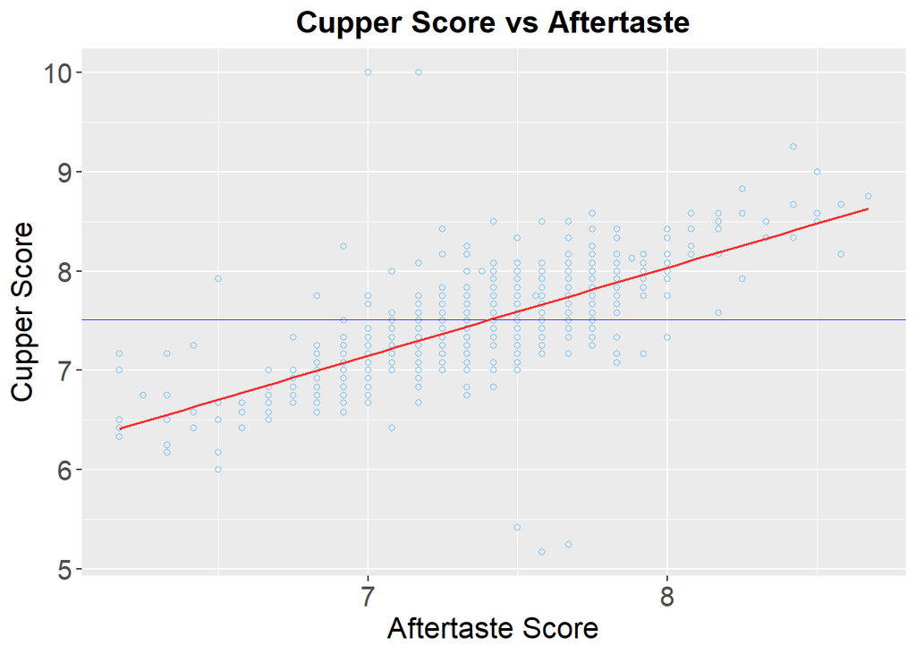

| term | estimate | std.error | statistic | p.value |
| --- | --- | --- | --- | --- |
| (Intercept) | 0.9363261 | 0.16939157 | 5.527584 | 3.899601e-08 |
| Aftertaste | 0.8874038 | 0.02284479 | 38.844904 | 1.568976e-221 |

We can describe our linear regression model with the following equation:
$$f(Cupper.Score) = {0.94} +
{0.887} Aftertaste$$

We obtain the following conclusions:

> *For one extra value in aftertaste, the cupper score increase by 0.887. Which denotes a positive relation, the more aftertaste, the higher the score.*

> *The p-values = 1.57e-221 shows high signicancy in the relation between the cupper score and the aftertaste.*

**6.3.4. Cupper Score in function of the Acidity**

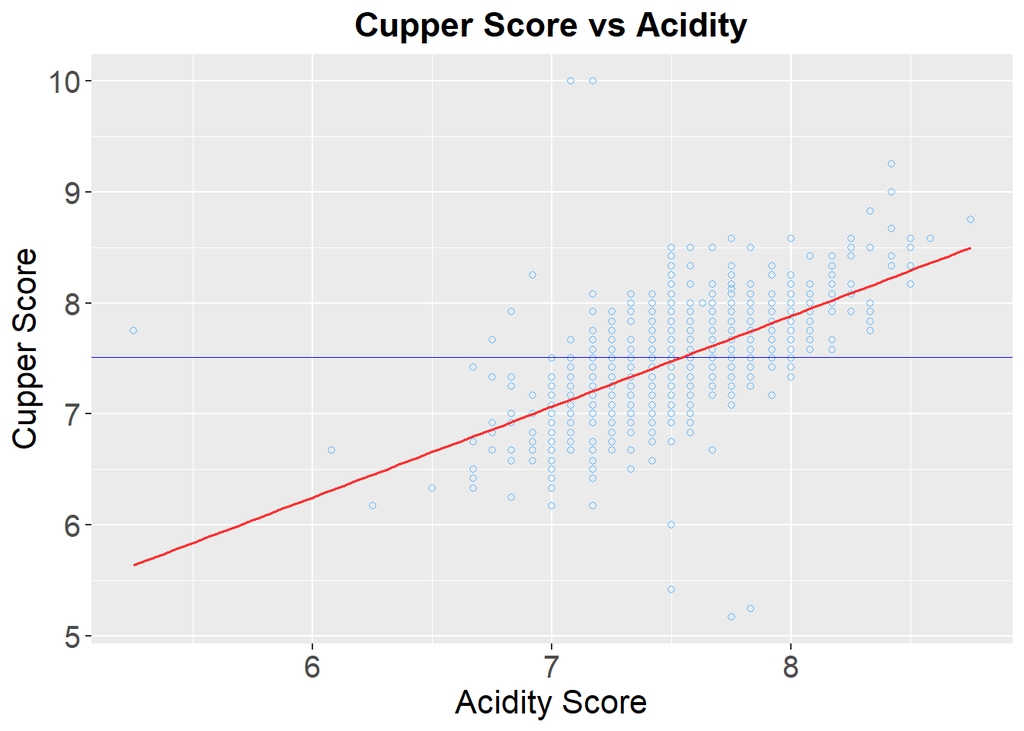

| term | estimate | std.error | statistic | p.value |
| --- | --- | --- | --- | --- |
| (Intercept) | 1.3407492 | 0.21849568 | 6.136273 | 1.111279e-09 |
| Acidity | 0.8179231 | 0.02894717 | 28.255717 | 4.328936e-138 |

We can describe our linear regression model with the following equation:
$$f(Cupper.Score) = {1.34} +
{0.818} Acidity$$

We obtain the following conclusions:

> *For one extra value in acidity, the cupper score increase by 0.818. Which denotes a positive relation, the more acidity, the higher the score.*

> *The p-values = 4.33e-138 shows high signicancy in the relation between the cupper score and the acidity.*

**6.3.5. Cupper Score in function of the Body**

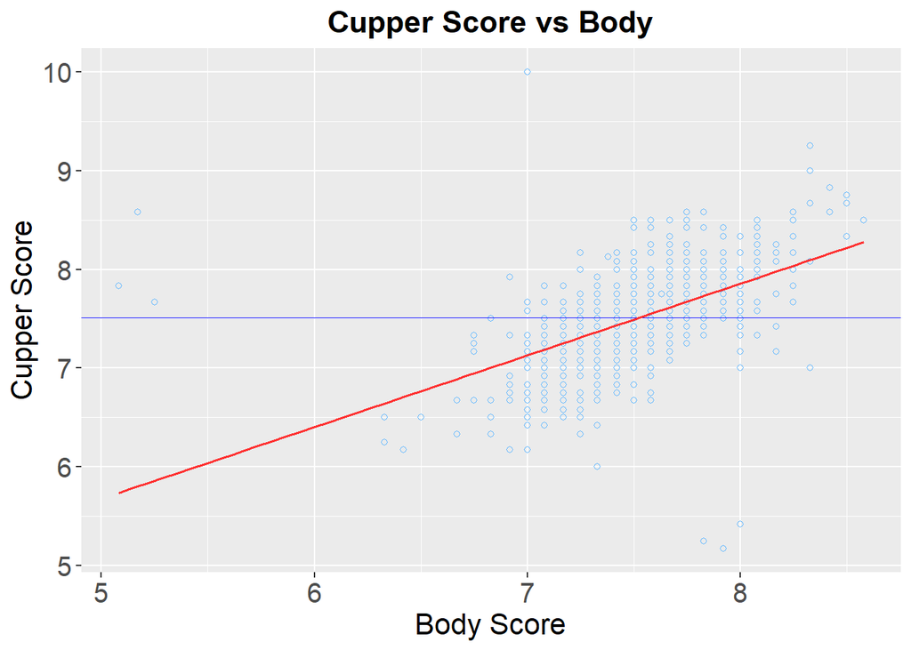

| term | estimate | std.error | statistic | p.value |
| --- | --- | --- | --- | --- |
| (Intercept) | 2.0456217 | 0.24334714 | 8.406187 | 1.071681e-16 |
| Body | 0.7262099 | 0.03231956 | 22.469669 | 4.166411e-95 |

We can describe our linear regression model with the following equation:
$$f(Cupper.Score) = {2.05} +
{0.726} Body$$

We obtain the following conclusions:

> *For one extra value in body, the cupper score increase by 0.726. Which denotes a positive relation, the more body, the higher the score.*

> *The p-values = 4.17e-95 shows high signicancy in the relation between the cupper score and the body.*

**6.3.6. Cupper Score in function of the Balance**

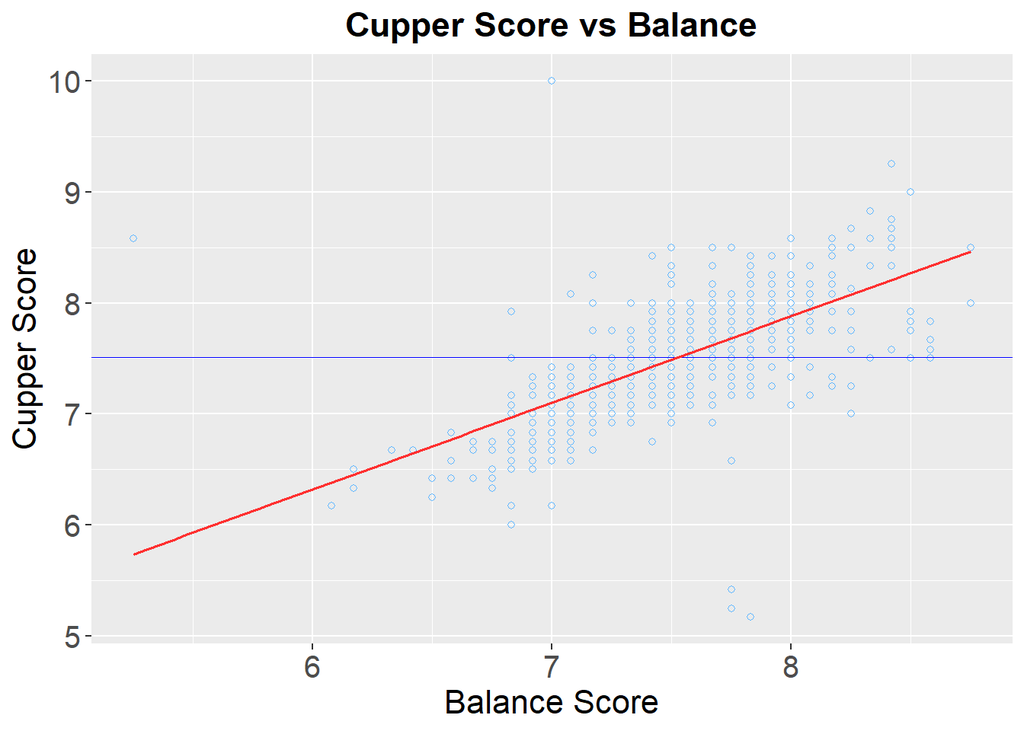

| term | estimate | std.error | statistic | p.value |
| --- | --- | --- | --- | --- |
| (Intercept) | 1.6426759 | 0.18986706 | 8.651716 | 1.432331e-17 |
| Balance | 0.7797175 | 0.02520828 | 30.931006 | 7.105797e-159 |

We can describe our linear regression model with the following equation:
$$f(Cupper.Score) = {1.64} +
{0.780} Balance$$

We obtain the following conclusions:

> *For one extra value in balance, the cupper score increase by 0.780. Which denotes a positive relation, the more balance, the higher the score.*

> *The p-values = 7.11e-159 shows high signicancy in the relation between the cupper score and the balance.*

**6.3.7. Cupper Score in function of the Uniformity**

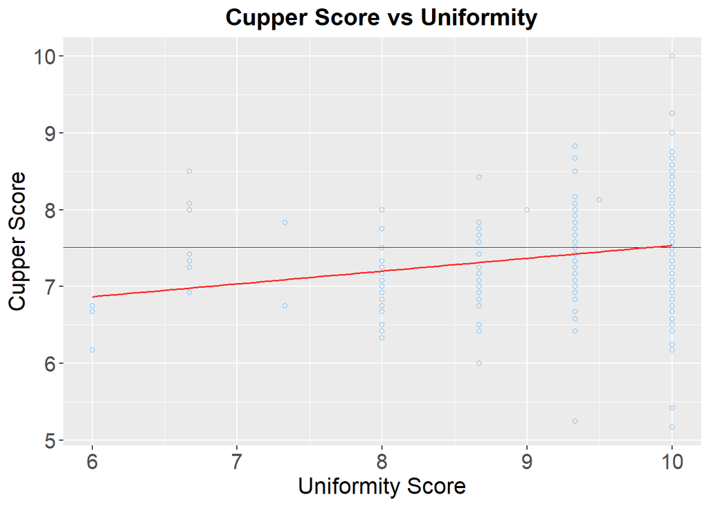

| term | estimate | std.error | statistic | p.value |
| --- | --- | --- | --- | --- |
| (Intercept) | 5.8673614 | 0.23287926 | 25.194865 | 6.375850e-115 |
| Uniformity | 0.1667938 | 0.02363256 | 7.057795 | 2.709957e-12 |

We can describe our linear regression model with the following equation:
$$f(Cupper.Score) = {5.87} +
{0.167} Uniformity$$

We obtain the following conclusions:

> *For one extra value in uniformity, the cupper score increase by 0.167. Which denotes a positive relation, the more uniformity, the higher the score.*

> *The p-values = 2.71e- 12 shows high signicancy in the relation between the cupper score and the uniformity.*

**6.3.8. Cupper Score in function of the Clean Cup**

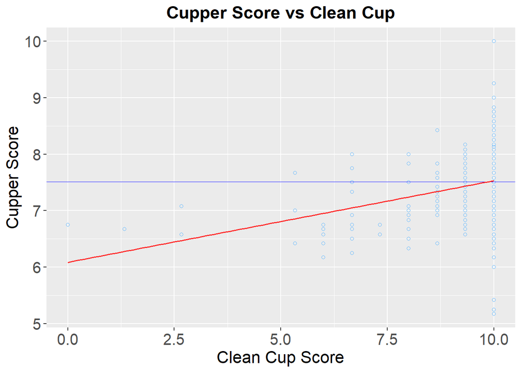

| term | estimate | std.error | statistic | p.value |
| --- | --- | --- | --- | --- |
| (Intercept) | 6.0857484 | 0.15630958 | 38.933945 | 3.088790e-222 |
| Clean.Cup | 0.1446016 | 0.01583941 | 9.129229 | 2.476868e-19 |

We can describe our linear regression model with the following equation:
$$f(Cupper.Score) = {6.09} +
{0.145} Clean.Cup$$

We obtain the following conclusions:

> *For one extra value in clean cup, the cupper score increase by 0.145. Which denotes a positive relation, the more clean cup, the higher the score.*

> *The p-values = 2.48e- 19 shows high signicancy in the relation between the cupper score and the clean cup.*

**6.3.9. Cupper Score in function of the Sweetness**

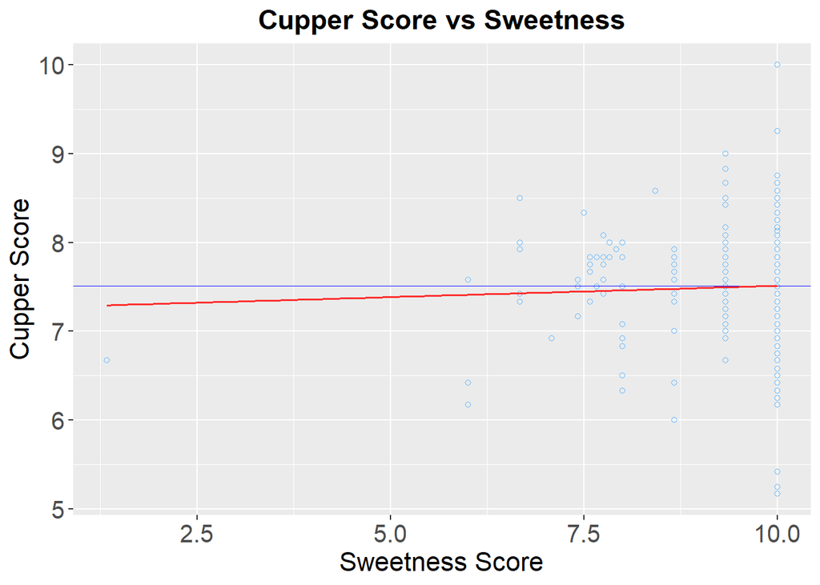

| term | estimate | std.error | statistic | p.value |
| --- | --- | --- | --- | --- |
| (Intercept) | 7.25924293 | 0.20806436 | 34.889410 | 3.957649e-190 |
| Sweetness | 0.02531824 | 0.02105999 | 1.202196 | 2.295005e-01 |

We can describe our linear regression model with the following equation:
$$f(Cupper.Score) = {7.26} +
{0.0253} Sweetness$$

We obtain the following conclusions:

> *For one extra value in sweetness, the cupper score increase by 0.0253. Which denotes a positive relation, the more sweetness, the higher the score.*

> *The p-values = 2.30e-1 shows low signicancy in the relation between the cupper score and the sweetness.*

# 7 7. General conclusions

- It would be recommended to provide support and training to the producer which does not measure values like moisture, altitude, or processing method. As well as to identify to which species and variety do belong the coffee beans they are producing. All these are in order to complete the data set and set a proper documentation process for future analysis.
- It would be highly recommended to try to identify which type of variety are the unknown coffees, classified as “Other”, as they represent approximately 25% of the whole sample. This group has many similar scores and dispersion behaviour as Typica and Bourbon, it could be possible to find important insight inside this group.
- About 60% of the coffee from Haiti is below the 80-points cupper score, which means most of it does not fall in the speciality coffee category. It would be recommended to evaluate how profitable is to buy this coffee. But as we do not have financial data, it would depend on the business strategy of the trading company.
- On average the Processing Method does not affect the scores of the coffees inside this sample. Each group has more than 50 % of the coffees in between the 80 to 85 points range. We can observe that honey washed coffees had become a high-quality product, with 100% of these coffees are above the 80 points score. It might be worth it to buy more Honey coffee beans.
- Best coffees are to be found in between the 1000 to 2000-meter altitude. Excepting a large group which falls in the 500 to 600 meters range. In order to increase the quality of the coffees on sale, it would be recommended to consider buying just coffees harvested above the 1000 meters.
- We have discovered that many of the coffee characteristics have extreme high significance concerning the cupper score as a response variable. To visually observe these p-values, we have ordered the coffee characteristics decreasingly in the function of the significance as follows:

| ORDER | CHARACTERISTIC | P-VALUE | SIGNIFICANCE |
| --- | --- | --- | --- |
| 1 | Flavor | 2.73e-230 | Very High |
| 2 | Aftertaste | 1.57e-221 | Very High |
| 3 | Balance | 7.11e-159 | Very High |
| 4 | Acidity | 4.33e-138 | Very High |
| 5 | Aroma | 8.03e-130 | Very High |
| 6 | Body | 4.17e-95 | Very High |
| 7 | Clean Cup | 2.48e- 19 | High |
| 8 | Sweetness | 0.230 | None |

> The last table could be of great use for both, supplier and buyers. As it shows which coffees characteristics are more considered when a coffee taster assesses a coffee sample.
- We consider that more important than the coffee characteristics are the following variables, also sorted decreasingly in the function of the significance:

| ORDER | CHARACTERISTIC | P-VALUE | SIGNIFICANCE |
| --- | --- | --- | --- |
| 1 | Two Defects Category | 1.13e-15 | High |
| 2 | Moisture | 9.595e-13 | High |
| 3 | Altitude | 9.5e-7 | High |
| 4 | One Defects Category | 1.9e-1 | None |

> We would recommend focusing on these variables, as it is possible to change them. In other words, we can try to implement changes on them, so we can improve the individual scores. Therefore, to improve the Cupper Score and the Total Cupping Score.